# 03-Variable Aleatoria Continua Unidimensional

Probabilidad Aplicada 3-602

# Variable Aleatoria Continua

Una variable aleatoria continua es un valor numérico obtenido al azar, el cual resulta de hacer un experimento y que puede tomar infinitos valores. Esto significa que, conocidos dos valores consecutivos de la variable, siempre es posible encontrar otro valor intermedio entre ellos.

# Función de densidad

El histograma de frecuencias es muy útil para analizar la distribución de datos. Sin embargo depende del número de grupos o intervalos elegidos. Para resolver este problema, se utilizan las funciones de densidad, que es la curva resultante al considerar un número infinito de intervalos de longitud tendiente a cero que proporcionan infinitas barras (barras que tienden a lineas), cuyas alturas determinan la forma de la curva.

# Gráficas con ggplot + geom_density()

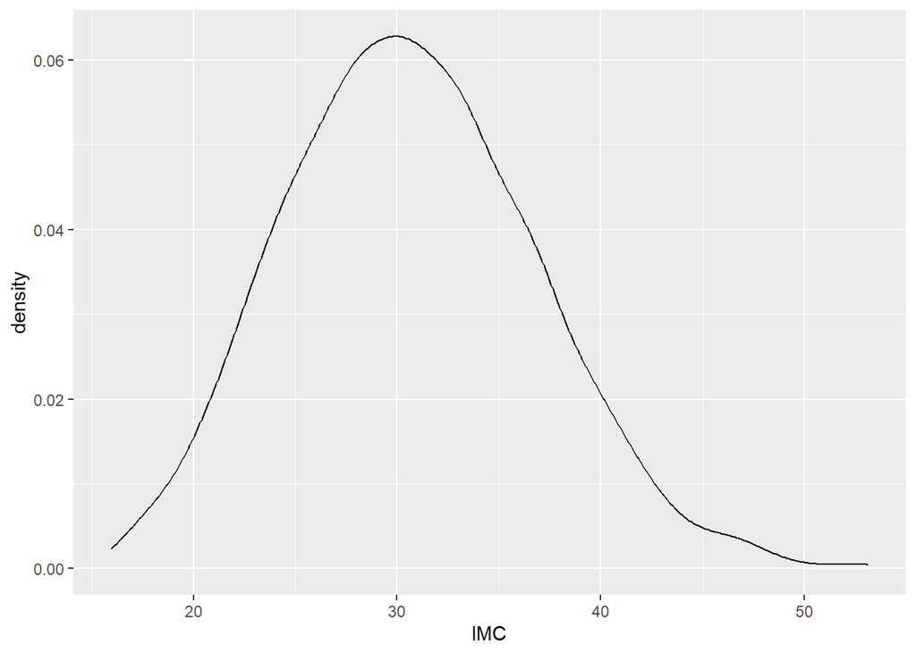

```r
densidad_01 <- ggplot(data = insurance, aes(x = IMC)) + geom_density()
```

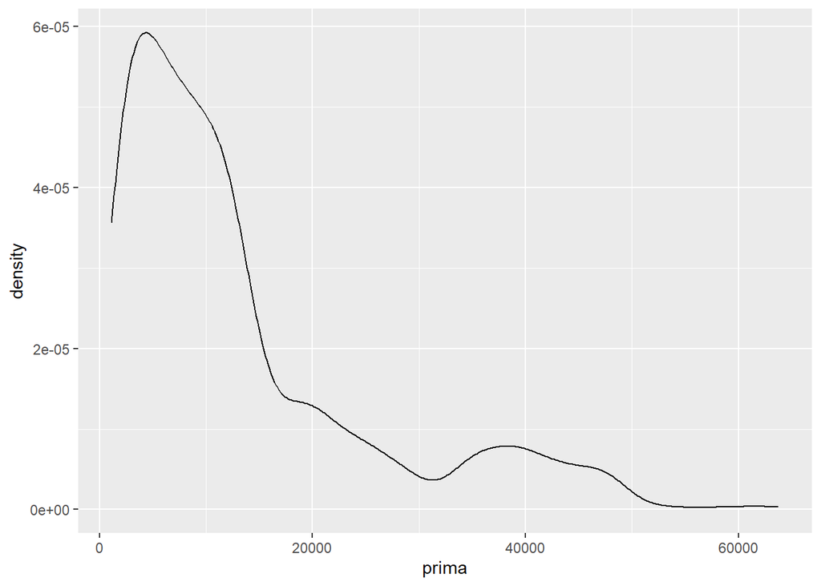

```r
densidad_02 <- ggplot(data = insurance, aes(x = prima)) + geom_density()
```

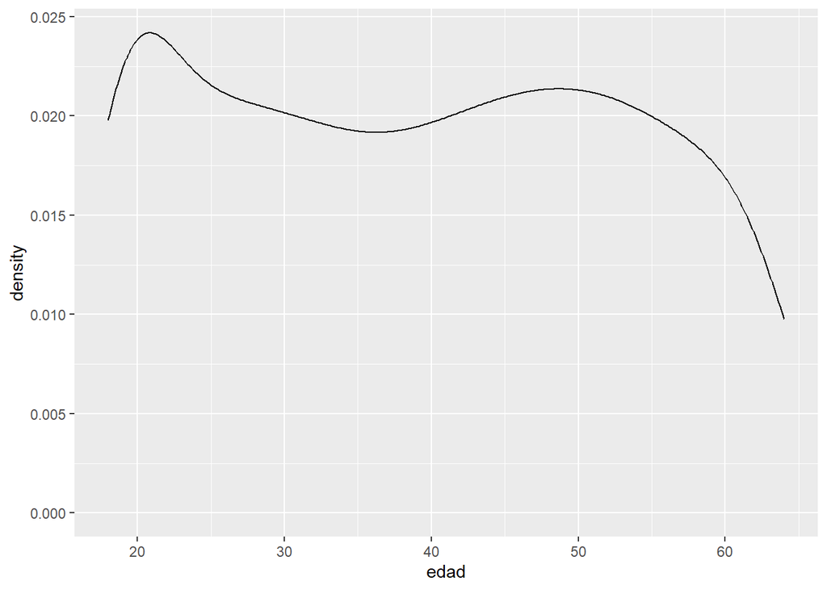

```r
densidad_03 <- ggplot(data = insurance, aes(x = edad)) + geom_density()
```

# Mejorando las visualizaciones: Agregando color.

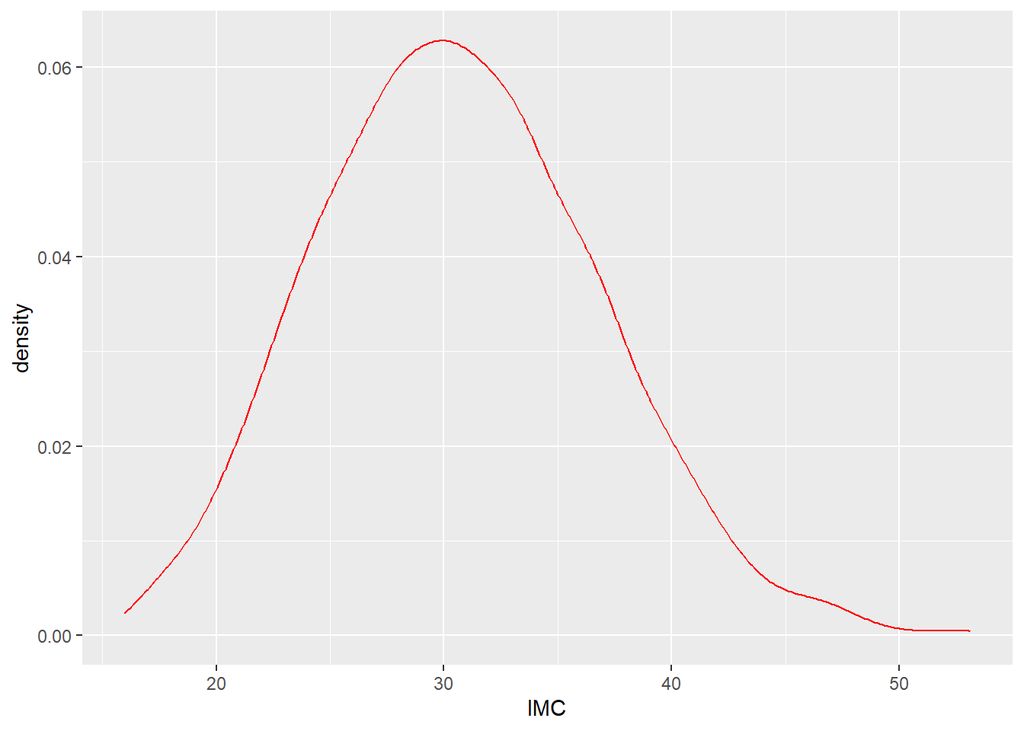

```r
densidad_04 <- ggplot(data = insurance, aes(x = IMC)) + geom_density(color = "red")
```

# Mejorando las visualizaciones: Agregando filtrado por variable categórica.

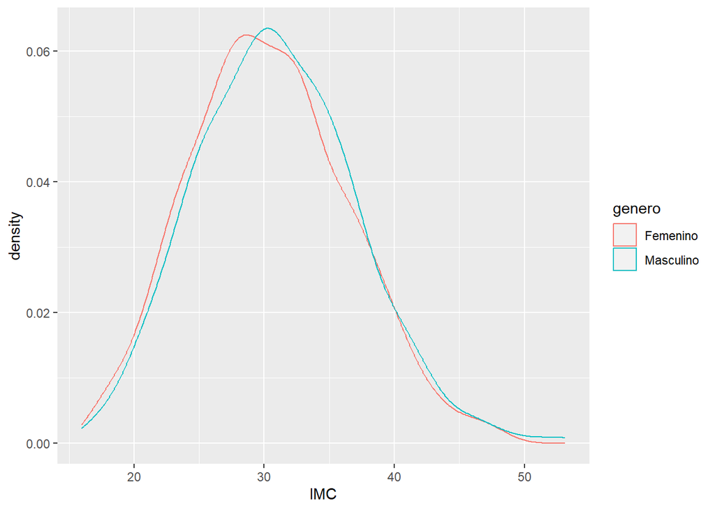

```r
densidad_05 <- ggplot(data = insurance, aes(x = IMC, colour = genero)) + geom_density()
```

# Mejorando las visualizaciones: Agregando filtrado por variable categórica y rellenando.

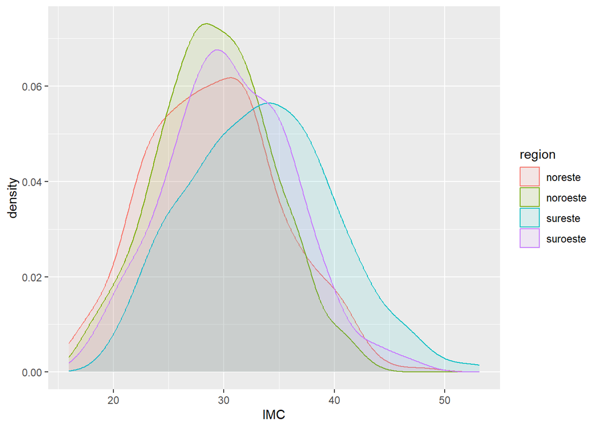

```r
densidad_06 <- ggplot(data = insurance, aes(x = IMC, colour = region, fill = region)) +
    geom_density(alpha = 0.1)
```

# Mejorando las visualizaciones: Agregando linea de media.

```r
densidad_07 <- ggplot(data = insurance, aes(x = IMC)) + geom_density(color = "red") +
    geom_vline(aes(xintercept = mean(IMC)), linetype = "dashed")
```

En este código, la función **mean(IMC)** proporciona la **media** de la variable IMC.

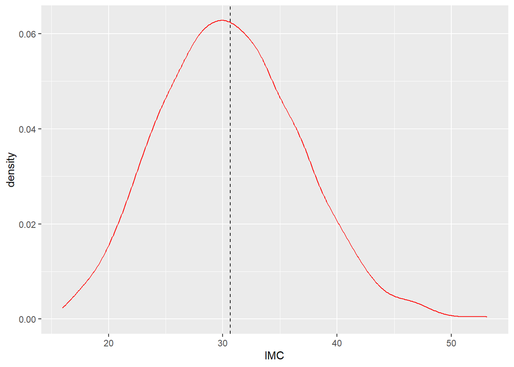

# Mejorando las visualizaciones: Agregando linea de mediana.

```r
densidad_08 <- ggplot(data = insurance, aes(x = IMC)) + geom_density(color = "red") +
    geom_vline(aes(xintercept = median(IMC)), linetype = "dashed")
```

En este código, la función **median(IMC)** proporciona la **mediana** de la variable IMC.

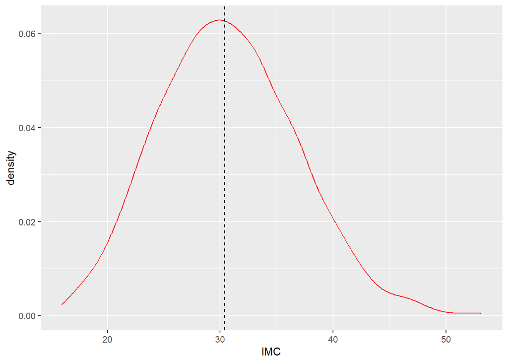

# Mejorando las visualizaciones: Agregando linea de moda.

Para calcular la moda, es necesario cargar el paquete **modeest**.

```r
densidad_09 <- ggplot(data = insurance, aes(x = IMC)) + geom_density(color = "red") +
    geom_vline(aes(xintercept = mfv(IMC)), linetype = "dashed")
```

En este código, la función **mfv(IMC)** (mfv() de modeest) proporciona la **moda** de la variable IMC.

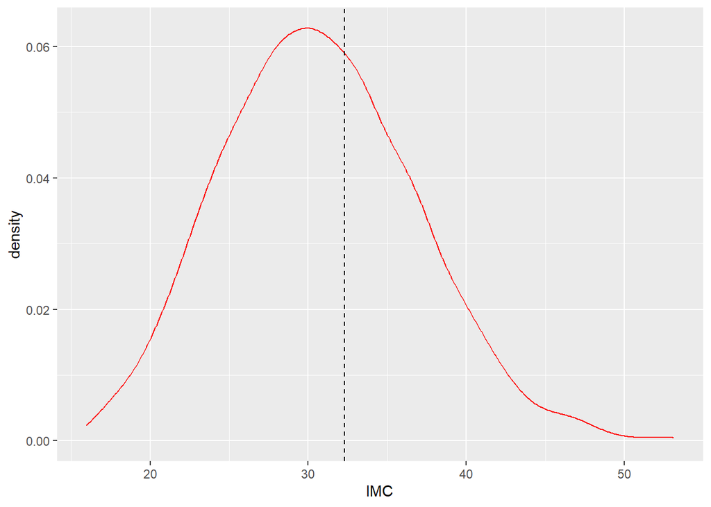

# Las tres mediadas de tendencia central en un gráfico de densidad.

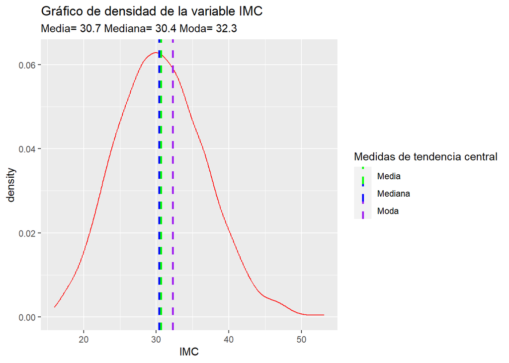

```r
titulo <- "Gráfico de densidad de la variable IMC" #Definimos un título

subtitulo <- paste("Media=",round(mean(insurance$IMC),1),
                   "Mediana=",median(insurance$IMC),
                   "Moda=",mfv(insurance$IMC)) #definimos un subtítulo que lleve los valores de las medidas

densidad_10 <- ggplot(data = insurance, aes(x = IMC)) + #creamos ggplot
  ggtitle(titulo,subtitle = subtitulo)+#creamos una capa para el título/subtítulo
  geom_density(color="red") + #Creamos la capa con el gráfico de densidad
  geom_vline(aes(xintercept = mean(IMC),color="Media"), linetype = "dashed",linewidth=1)+
  geom_vline(aes(xintercept = median(IMC),color="Mediana"), linetype = "dashed",linewidth=1)+
  geom_vline(aes(xintercept = mfv(IMC),color="Moda"), linetype = "dashed",linewidth=1)+
  #creamos las capas con las rectas verticales de la tendencia central
  scale_color_manual(name= "Medidas de tendencia central",
                      breaks=c("Media","Mediana","Moda"),
                        values =c("Media"="green","Mediana"="blue","Moda"="purple"))
#creamos una escalar de color manual para poder referenciar.
```